# EDA

## Engine Sizes

by Franklin Doane

```r
library(huxtable)
library(dplyr)

df <- read.csv("bmw.csv")
```

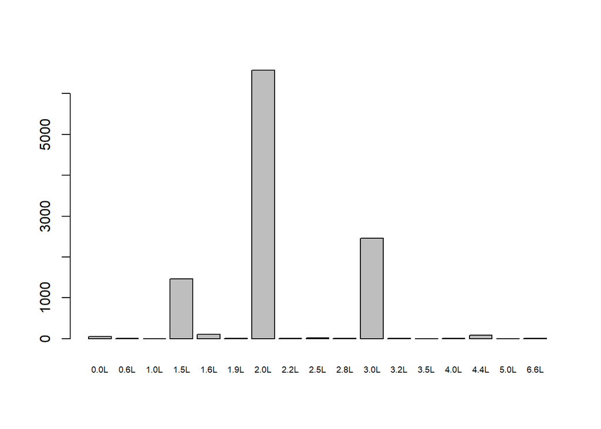

| engineSizeStr | 0.0L | 0.6L | 1.0L | 1.5L | 1.6L | 1.9L | 2.0L | 2.2L | 2.5L | 2.8L | 3.0L | 3.2L | 3.5L | 4.0L | 4.4L | 5.0L | 6.6L |
| --- | --- | --- | --- | --- | --- | --- | --- | --- | --- | --- | --- | --- | --- | --- | --- | --- | --- |
| n | 47 | 7 | 1 | 1463 | 109 | 5 | 6575 | 6 | 14 | 2 | 2458 | 5 | 1 | 6 | 79 | 1 | 2 |

Here we can see that the 2.0L (4-cylinder) engine and the 3.0 liter (6-cylinder) engine are the most popular

The largest engine size is the 6.6 liter V12, and the smallest is the 0.6 liter 2-cylinder

```r
df[df$engineSize == 0 & df$fuelType == "Electric", c("model", "fuelType", "engineSize")]
```

| model | fuelType | engineSize |
| --- | --- | --- |
| i3 | Electric | 0 |
| i3 | Electric | 0 |

Note that 47 cars have an engine size of 0, and only 2 of them are electric

| fuelType | Diesel | Electric | Hybrid | Other | Petrol |
| --- | --- | --- | --- | --- | --- |
| n | 7027 | 3 | 298 | 36 | 3417 |

| model | fuelType | engineSize |
| --- | --- | --- |
| i3 | Electric | 0 |
| i3 | Electric | 0 |
| i3 | Electric | 1 |

On the flip side, there are 3 total electric cars, and 1 has a non-0 engine size

Both of these issues may require cleaning

## Models

by Franklin Doane

There are 24 different model types. The most popular series are 3, 1, 2, 5, and 4

| model | 1 Series | 2 Series | 3 Series | 4 Series | 5 Series | 6 Series | 7 Series | 8 Series | M2 | M3 | M4 | M5 | M6 | X1 | X2 | X3 | X4 | X5 | X6 | X7 | Z3 | Z4 | i3 | i8 |
| --- | --- | --- | --- | --- | --- | --- | --- | --- | --- | --- | --- | --- | --- | --- | --- | --- | --- | --- | --- | --- | --- | --- | --- | --- |
| n | 1969 | 1229 | 2443 | 995 | 1056 | 108 | 106 | 39 | 21 | 27 | 125 | 29 | 8 | 804 | 288 | 551 | 179 | 468 | 106 | 55 | 7 | 108 | 43 | 17 |

```
## [1] 24  model types
```

```
## [1] 22.7 % 3 series
```

```
## [1] 18.3 % 1 series
```

```
## [1] 11.4 % 2 series
```

```
## [1] 9.8 % 5 series
```

```
## [1] 9.2 % 4 series
```

Also worth noting is that all series names have proceeding spaces which should be cleaned

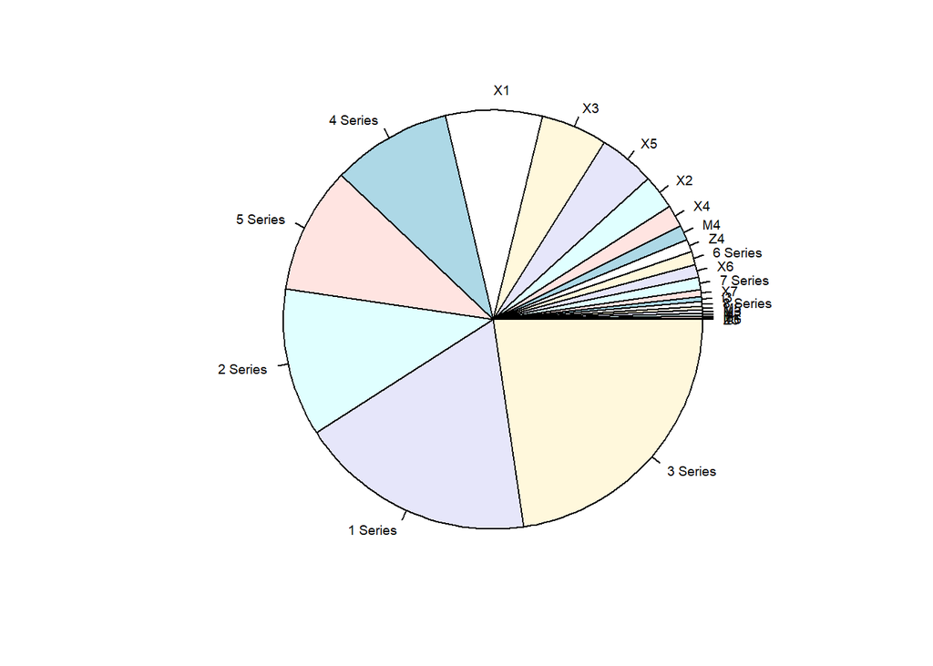

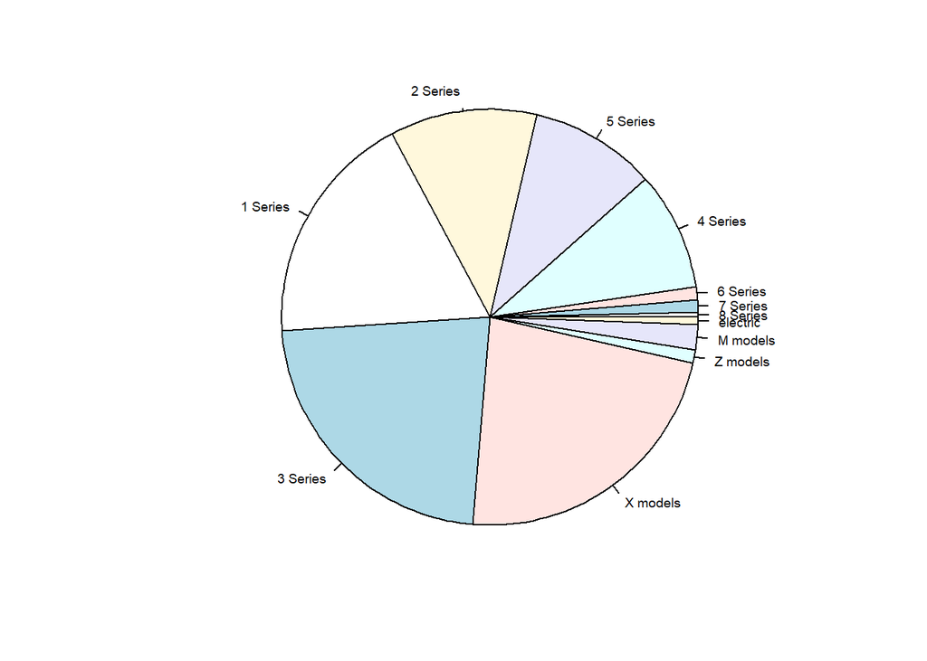

The second pie chart is simplified a bit, grouping some of the model types

X models: suvs

M models: high performance

Z models: 2-seat roadsters

## Transmission

by Will Ward

```r
library(tidyverse)
df <- read.csv("bmw.csv")
summary(df)
```

```
##     model                year          price        transmission
##  Length:10781       Min.   :1996   Min.   :  1200   Length:10781
##  Class :character   1st Qu.:2016   1st Qu.: 14950   Class :character
##  Mode  :character   Median :2017   Median : 20462   Mode  :character
##                     Mean   :2017   Mean   : 22733
##                     3rd Qu.:2019   3rd Qu.: 27940
##                     Max.   :2020   Max.   :123456
##     mileage         fuelType              tax             mpg
##  Min.   :     1   Length:10781       Min.   :  0.0   Min.   :  5.5
##  1st Qu.:  5529   Class :character   1st Qu.:135.0   1st Qu.: 45.6
##  Median : 18347   Mode  :character   Median :145.0   Median : 53.3
##  Mean   : 25497                      Mean   :131.7   Mean   : 56.4
##  3rd Qu.: 38206                      3rd Qu.:145.0   3rd Qu.: 62.8
##  Max.   :214000                      Max.   :580.0   Max.   :470.8
##    engineSize
##  Min.   :0.000
##  1st Qu.:2.000
##  Median :2.000
##  Mean   :2.168
##  3rd Qu.:2.000
##  Max.   :6.600
```

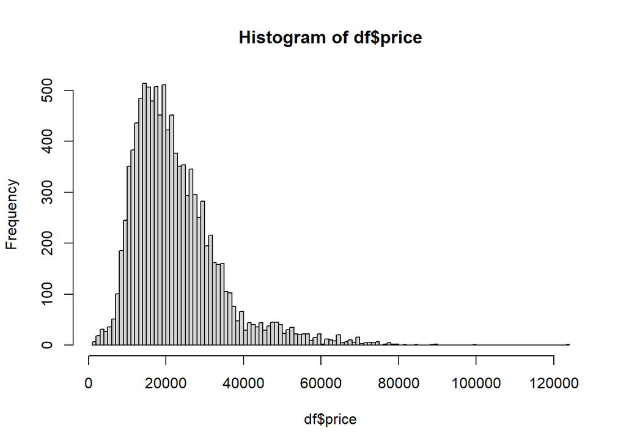

```r
hist(df$price, breaks=100)
```

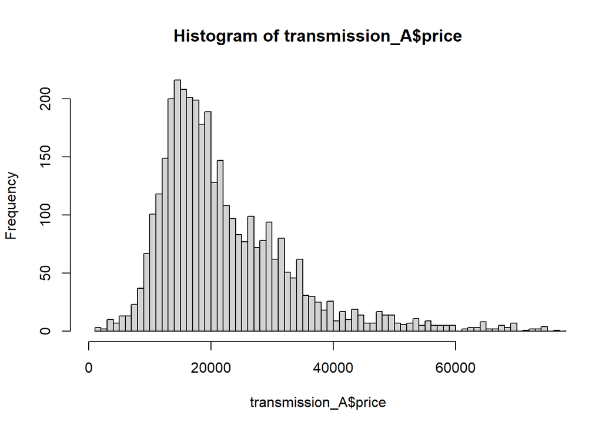

```r
transmission_A <- df %>% filter(transmission=="Automatic")
transmission_Semi <- df %>% filter(transmission=="Semi-Auto")
transmission_M <- df %>% filter(transmission=="Manual")

hist(transmission_A$price, breaks = 100, xlim=c(0,75000))
```

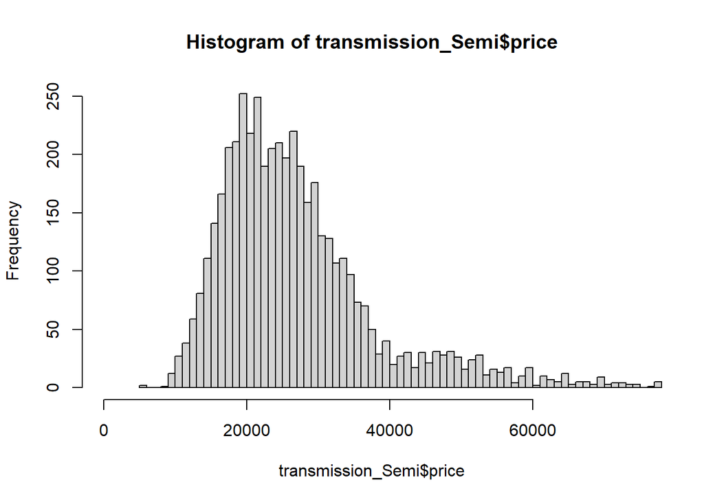

```r
hist(transmission_Semi$price, breaks = 100, xlim=c(0,75000))
```